# Prediction Assignment Writeup

Rui Romanini

2016, February 3

## Summary

One thing that people regularly do is quantify how much of a particular activity they do, but they rarely quantify how well they do it. In this project, your goal will be to use data from accelerometers on the belt, forearm, arm, and dumbell of 6 participants.

The goal of this project is to predict the manner in which they did the exercise. This is the “classe” variable in the training set. You may use any of the other variables to predict with. You should create a report describing how you built your model, how you used cross validation, what you think the expected out of sample error is, and why you made the choices you did. You will also use your prediction model to predict 20 different test cases.

## The environment

For this study we used R version 3.3.1 and R Studio version 0.99.489

The Operational System it’s Windows 10 Home

The used libraries are loaded here

```r
#Package for plotting
install.packages("ggplot2", repos ="http://cran.us.r-project.org")
#Package for GBM
install.packages("gbm", repos ="http://cran.us.r-project.org")
install.packages("plyr", repos ="http://cran.us.r-project.org")
#Package for machine learning
install.packages("caret", repos ="http://cran.us.r-project.org")
#Package for plotting
install.packages("e1071", repos ="http://cran.us.r-project.org")
```

[output not shown]

```r
#Another package for plotting
install.packages("rattle", repos ="http://cran.us.r-project.org")
install.packages("rpart.plot", repos ="http://cran.us.r-project.org")
library(ggplot2)
library(caret)
library(gbm)
library(plyr)
library(e1071)
library(caret)
library(rattle)
library(rpart.plot)
#Important to get the same sample ever
set.seed(1234)
```

## Getting data

The training data for this project are available here:

https://d396qusza40orc.cloudfront.net/predmachlearn/pml-training.csv

The test data are available here:

https://d396qusza40orc.cloudfront.net/predmachlearn/pml-testing.csv

```r
#Download training file
fileURL = "https://d396qusza40orc.cloudfront.net/predmachlearn/pml-training.csv";
download.file(fileURL,destfile="./pml-training.csv",
              method="auto")
trainingDataSet <- read.csv("./pml-training.csv" ,sep = ",",header = TRUE)
```

```r
#Download testing file
fileURL = "https://d396qusza40orc.cloudfront.net/predmachlearn/pml-testing.csv";
download.file(fileURL,destfile="./pml-testing.csv",
              method="auto")
testingDataSet <- read.csv("./pml-testing.csv" ,sep = ",",
                           header = TRUE)
```

## Cleaning Data

When we take a look in the csv file, it’s easy to see several NA values in the dataset.

We choose to remove near zero covariates and the records with more than 80% missing values because these variables will not provide much power for prediction.

Plot the two features that have highest correlation with classe and color with classe to see if we can separate response based on these features.

```r
# remove near zero covariates
nsv <- nearZeroVar(trainingDataSet, saveMetrics = T)

trainingDataSet <- trainingDataSet[, !nsv$nzv]

# remove variables with more than 80% missing values
nav <- sapply(colnames(trainingDataSet), function(x) if(sum(is.na(trainingDataSet[, x])) > 0.8*nrow(trainingDataSet)){return(T)}else{return(F)})

trainingDataSet <- trainingDataSet[, !nav]

# calculate correlations
cor <- abs(sapply(colnames(trainingDataSet[, -ncol(trainingDataSet)]), function(x) cor(as.numeric(trainingDataSet[, x]), as.numeric(trainingDataSet$classe), method = "spearman")))
```

## Plot Predictors

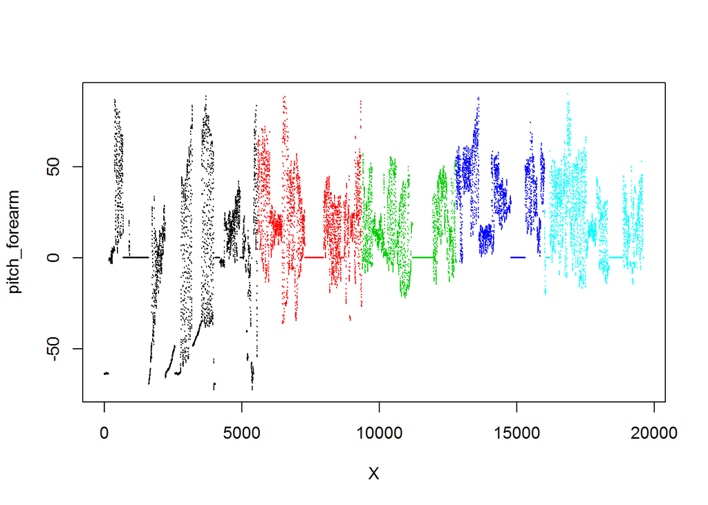

```r
plot(trainingDataSet[, names(which.max(cor))], trainingDataSet[, names(which.max(cor[-which.max(cor)]))], col = trainingDataSet$classe, pch = 19, cex = 0.1, xlab = names(which.max(cor)), ylab = names(which.max(cor[-which.max(cor)])))
```

## Fitting Model using Boost

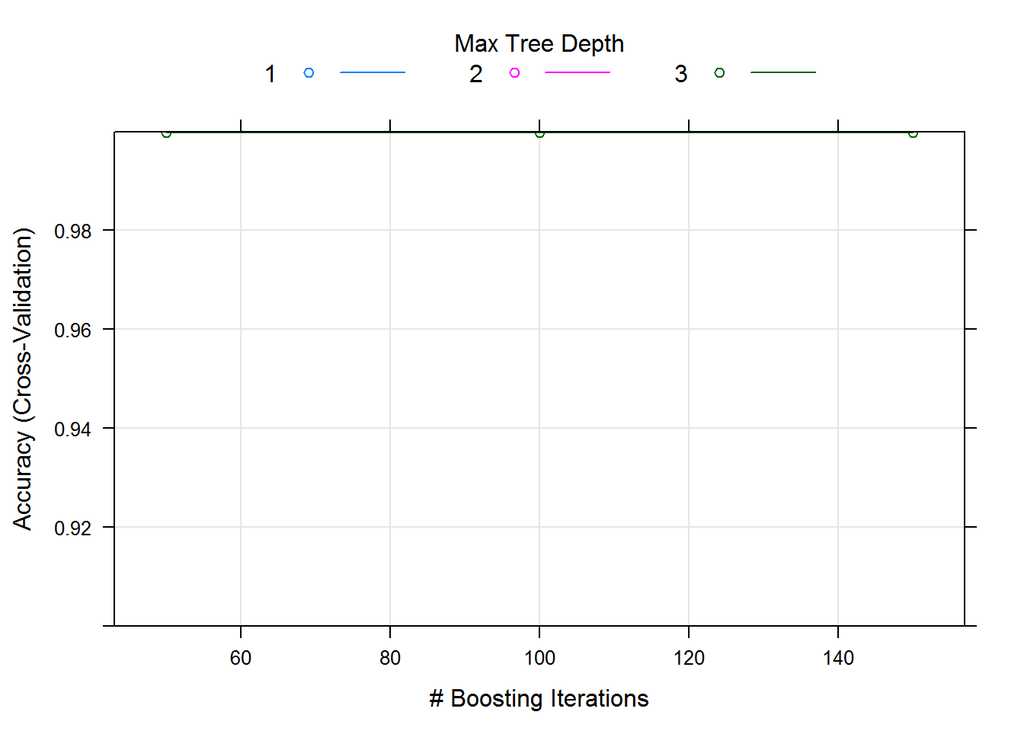

```r
boostFit <- train(classe ~ ., method = "gbm", data = trainingDataSet, verbose = F, trControl = trainControl(method = "cv", number = 10))


plot(boostFit, ylim = c(0.9, 1))
```

The boosting algorithm generated a good model with accuracy = 0.997. Random forests model

## Fitting Model using Random Forest

```r
set.seed(123)
rfFit <- train(classe ~ ., method = "rf", data = trainingDataSet, importance = T, trControl = trainControl(method = "cv", number = 10))
```

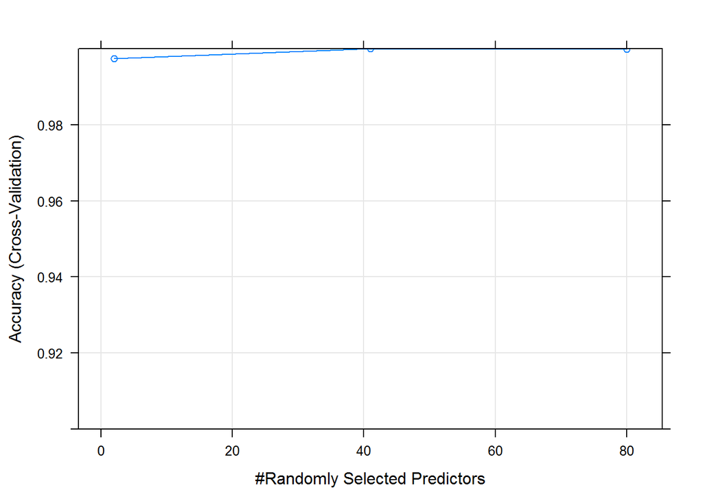

```r
plot(rfFit, ylim = c(0.9, 1))
```

```r
imp <- varImp(rfFit)$importance
imp$max <- apply(imp, 1, max)
imp <- imp[order(imp$max, decreasing = T), ]
```

## Conclusion

The random forests algorithm generated a very accurate model with accuracy close to 1. Compared to boosting model, this model generally has better performance in terms of accuracy as we see from the plots. Final model and prediction

```
Now, we can predict the testing dataset and output results for automatic grader.
```

```r
# final model
rfFit$finalModel
```

```
##
## Call:
##  randomForest(x = x, y = y, mtry = param$mtry, importance = ..1)
##                Type of random forest: classification
##                      Number of trees: 500
## No. of variables tried at each split: 41
##
##         OOB estimate of  error rate: 0.01%
## Confusion matrix:
##      A    B    C    D    E  class.error
## A 5580    0    0    0    0 0.0000000000
## B    1 3796    0    0    0 0.0002633658
## C    0    1 3421    0    0 0.0002922268
## D    0    0    0 3216    0 0.0000000000
## E    0    0    0    0 3607 0.0000000000
```

```r
# prediction
(prediction <- as.character(predict(rfFit, testingDataSet)))
```

```
##  [1] "A" "A" "A" "A" "A" "A" "A" "A" "A" "A" "A" "A" "A" "A" "A" "A" "A"
## [18] "A" "A" "A"
```

```r
# write prediction files
pml_write_files = function(x){
  n = length(x)
  for(i in 1:n){
    filename = paste0("./problem_id_", i, ".txt")
    write.table(x[i], file = filename, quote = FALSE, row.names = FALSE, col.names = FALSE)
  }
}
pml_write_files(prediction)
```